# Halomonas boliviensis mediated fabrication of polyhydroxyalkanoate using oil palm empty fruit bunch

Statistical Report Prepared by: Luis Carlos Beltrán, PhD

2024-08-28

# Loading Packages

We will start by loading some useful packages. Using the `library` function, we can load these packages if they have previously been installed in your `R`. If they have not been previously installed, replace the `library` function with `install.packages` function and place the package name in quotation marks. That will install the package. Next, run the `library` function again and it will load the package. You only need to install a package once.

```r
library(ggplot2) # Necessary for `ggplot` function.
library(dplyr) # Necessary for `%>%` and `mutate` function.
library(kableExtra) # Necessary for `kbl` function.
library(tidyr) # Necessary for `pivot_longer` function.
library(reshape2) # Necessary for `melt` function
library(Rmisc) # Necessary for the 'summarySE' function.
library(png) # Necessary for `png` function.
library(report) # Necessary for `report` function.
library(readxl) # Necessary for `read_excel` function.
library(ggpubr) # Necessary for `ggarrange` function.
library(multcomp) # Necessary for 'glht' function.
library(effects) # Necessary for 'allEffects' function.
```

# Dataframe Setup

## Loading Dataframes

We will set the working directory using the `setwd` function. If you are looking to run this code in your computer, be sure to change the path to your data! Normally we can load data frames using the `read.csv` function. Or, we can use the `read_excel` function from the `readxl` package and specify the sheet number!

```r
setwd("~/Desktop/R") # Set the working directory
EFB_Biomass <- read_excel("Data/EFB_Data.xlsx", sheet = 1)
EFB_PHB <- read_excel("Data/EFB_Data.xlsx", sheet = 2)
EFB_Sugars <- read_excel("Data/EFB_Data.xlsx", sheet = 3)
FruitBunch <- read_excel("Data/EFB_Data.xlsx", sheet = 4)
```

## Variable Formatting

We can convert multiple variables into numerical or factorial class by combining `as.numeric` or `as.factor` with the `mutate` function from the `dplyr` package as well as the `across` function on a `concatenated` list of our variables.

```r
EFB_Biomass <- EFB_Biomass %>%
  dplyr::mutate(across(c("Sugar", "Replicate"), as.factor))
EFB_PHB <- EFB_PHB %>%
  dplyr::mutate(across(c("Sugar", "Replicate"), as.factor))
EFB_Sugars <- EFB_Sugars %>%
  dplyr::mutate(across(c("Sugar", "Replicate"), as.factor))
FruitBunch <- FruitBunch %>%
  dplyr::mutate(across(c("Variable"), as.factor))
```

# Figures

Prior to making some prototype figures, we will need calculate averages and dispersion statistics. Luckily we can accomplish this with the help of the function `summarySE`.

```r
Biomass_tgc <- summarySE(EFB_Biomass, measurevar="Biomass_Concentration", groupvars=c("Time", "Sugar"), na.rm = TRUE)
PHB_tgc <- summarySE(EFB_PHB, measurevar="PHB_Concentration", groupvars=c("Time", "Sugar"), na.rm = TRUE)

EFB_Sugars2 <- EFB_Sugars %>%
  filter(!(Time == 0 &
            Sugar == "Arabinose" &
            Replicate == "A2"))

EFB_Sugars2 <- EFB_Sugars2 %>%
  filter(!(Time == 24 &
            Sugar == "Arabinose" &
            Replicate == "A1"))

EFB_Sugars2 <- EFB_Sugars2 %>%
  filter(!(Time == 28 &
            Sugar == "Arabinose" &
            Replicate == "A2"))

EFB_Sugars2 <- EFB_Sugars2 %>%
  filter(!(Time == 0 &
            Sugar == "Xylose" &
            Replicate == "X1"))

EFB_Sugars2 <- EFB_Sugars2 %>%
  filter(!(Time == 48 &
            Sugar == "Xylose" &
            Replicate == "X3"))

EFB_Sugars2 <- EFB_Sugars2 %>%
  filter(!(Time == 60 &
            Sugar == "Xylose" &
            Replicate == "X3"))

EFB_Sugars2 <- EFB_Sugars2 %>%
  filter(!(Time == 28 &
            Sugar == "Glucose" &
            Replicate == "G1"))

EFB_Sugars2 <- EFB_Sugars2 %>%
  filter(!(Time == 32 &
            Sugar == "Glucose" &
            Replicate == "G1"))

Sugars_tgc <- summarySE(EFB_Sugars2, measurevar="Sugar_Concentration", groupvars=c("Time", "Sugar"), na.rm = TRUE)
```

Next, let’s set the colors so that graphs that share levels use the same color for that variable.

```r
color_map2 <- c("Arabinose" = "#1B9E77",
               "Glucose" = "#D95F02",
               "Xylose" = "#7570B3",
               "Biomass" = "#E6AB02",
               "PHB" = "#1f78b4")
```

## Biomass

Let’s make a graph showing solely biomass concentration, comparing among sugars. Error bars here will represent standard error.

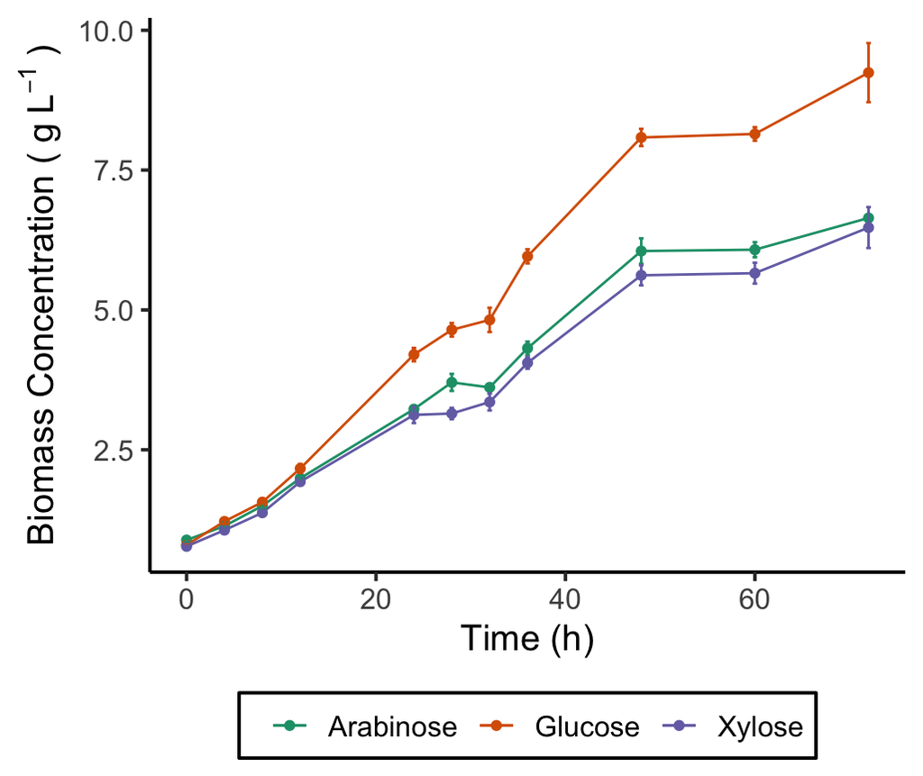

```r
GG_Biomass <- ggplot(Biomass_tgc, aes(x = Time, y = Biomass_Concentration, color = Sugar)) +
  geom_line() +
  geom_point() +
  geom_errorbar(aes(ymin = Biomass_Concentration - se, ymax = Biomass_Concentration + se), width = 0.5) +
  xlab("Time (h)") +
  ylab(expression("Biomass Concentration ( g" ~ L^-1~")")) +
  scale_color_manual(name = "", values = color_map2) +
  theme_classic(base_size = 15) +
  theme(legend.position = "bottom",
        legend.background = element_rect(color = "black"),
        legend.margin = margin(5, 5, 5, 5))
GG_Biomass
```

```r
png("~/Desktop/Freelance Work/Universidad de Antioquia/Natalia Gomez/Halomonas/Prototype Figures/Biomass.png",
    width = 140, height = 130, units = 'mm', res = 300)
GG_Biomass
dev.off()
```

## PHB

Now let’s create a graph showing the concentration of PHB by sugar substrate.

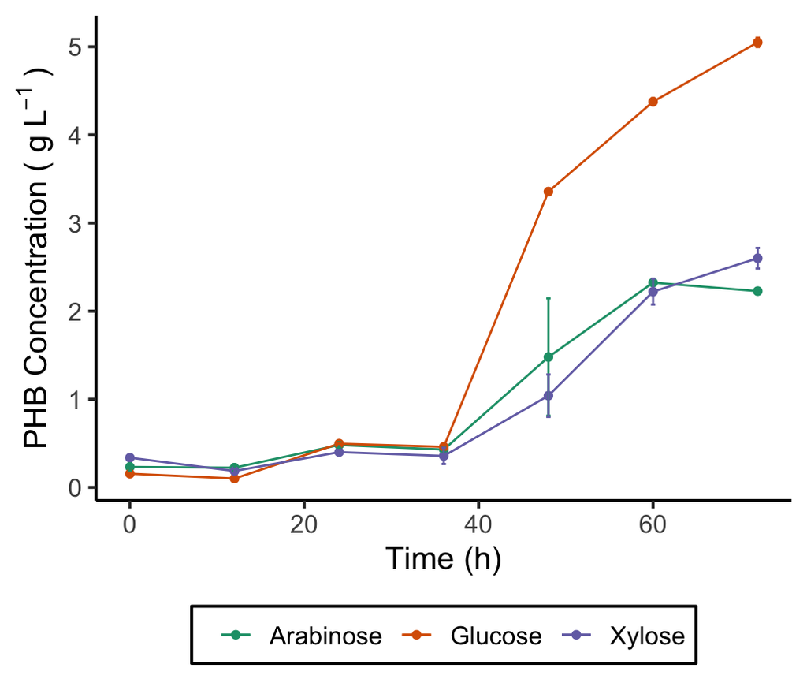

```r
GG_PHB <- ggplot(PHB_tgc, aes(x = Time, y = PHB_Concentration, color = Sugar)) +
  geom_line() +
  geom_point() +
  geom_errorbar(aes(ymin = PHB_Concentration - se, ymax = PHB_Concentration + se), width = 0.5) +
  xlab("Time (h)") +
  ylab(expression("PHB Concentration ( g" ~ L^-1~")")) +
  scale_color_manual(name = "", values = color_map2) +
  theme_classic(base_size = 15) +
  theme(legend.position = "bottom",
        legend.background = element_rect(color = "black"),
        legend.margin = margin(5, 5, 5, 5))
GG_PHB
```

```r
png("~/Desktop/Freelance Work/Universidad de Antioquia/Natalia Gomez/Halomonas/Prototype Figures/PHB.png",
    width = 140, height = 130, units = 'mm', res = 300)
GG_PHB
dev.off()
```

## Sugars

Finally, let’s take a look at sugar concentration, comparing among sugar substrates used.

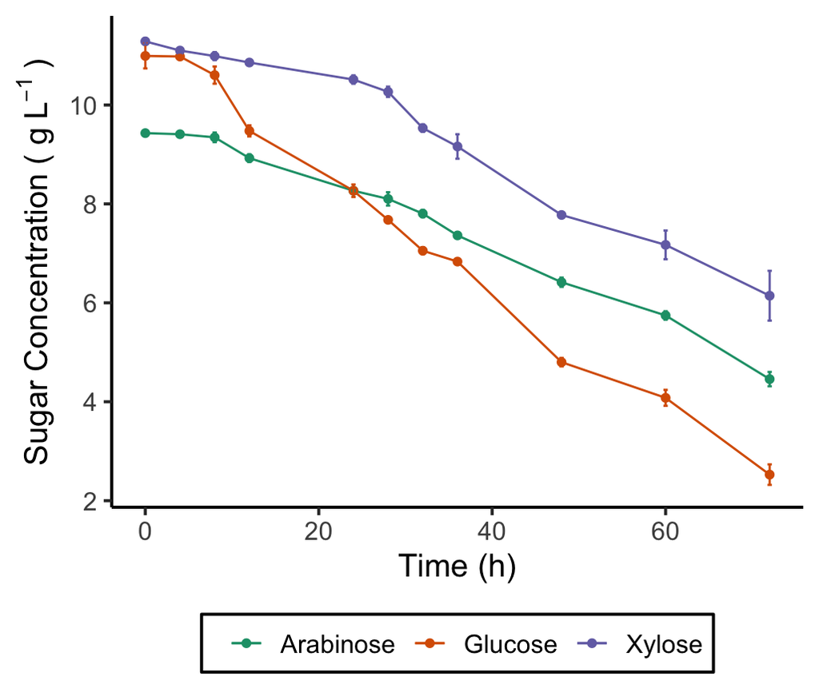

```r
GG_Sugars <- ggplot(Sugars_tgc, aes(x = Time, y = Sugar_Concentration, color = Sugar)) +
  geom_line() +
  geom_point() +
  geom_errorbar(aes(ymin = Sugar_Concentration - se, ymax = Sugar_Concentration + se), width = 0.5) +
  xlab("Time (h)") +
  ylab(expression("Sugar Concentration ( g" ~ L^-1~")")) +
  scale_color_manual(name = "", values = color_map2) +
  theme_classic(base_size = 15) +
  theme(legend.position = "bottom",
        legend.background = element_rect(color = "black"),
        legend.margin = margin(5, 5, 5, 5))
GG_Sugars
```

```r
png("~/Desktop/Freelance Work/Universidad de Antioquia/Natalia Gomez/Halomonas/Prototype Figures/Sugars.png",
    width = 140, height = 130, units = 'mm', res = 300)
GG_Sugars
dev.off()
```

Super! Now, we are going to want to work with the assay individually, so we will have to do some reconfiguring. Using the `subset` and `droplevels` functions, we will create new dataframes that separate the `Biomass_tgc`, `PHB_tgc`, and `Sugars_tgc` by sugar.

```r
BiomassGlucose <- droplevels(subset(Biomass_tgc, Biomass_tgc$Sugar == "Glucose"))
BiomassArabinose <- droplevels(subset(Biomass_tgc, Biomass_tgc$Sugar == "Arabinose"))
BiomassXylose <- droplevels(subset(Biomass_tgc, Biomass_tgc$Sugar == "Xylose"))

PHBGlucose <- droplevels(subset(PHB_tgc, PHB_tgc$Sugar == "Glucose"))
PHBArabinose <- droplevels(subset(PHB_tgc, PHB_tgc$Sugar == "Arabinose"))
PHBXylose <- droplevels(subset(PHB_tgc, PHB_tgc$Sugar == "Xylose"))

SugarsGlucose <- droplevels(subset(Sugars_tgc, Sugars_tgc$Sugar == "Glucose"))
SugarsArabinose <- droplevels(subset(Sugars_tgc, Sugars_tgc$Sugar == "Arabinose"))
SugarsXylose <- droplevels(subset(Sugars_tgc, Sugars_tgc$Sugar == "Xylose"))
```

Next we work with individual sugars.

Great. Now, we do have some extra columns here, so let’s use some bracket notation to specify that we only want the first, second, fourth, and sixth column, which correspond to the variables `Time`, `Sugar`, `Concentrations`, and `se`, which is standard error, our dispersion statistic of interest.

```r
BiomassArabinose <- BiomassArabinose[,c(1,2,4,6)]
PHBArabinose <- PHBArabinose[,c(1,2,4,6)]
SugarsArabinose <- SugarsArabinose[,c(1,2,4,6)]

BiomassArabinose$Variable <- "Biomass"
PHBArabinose$Variable <- "PHB"
SugarsArabinose$Sugars <- "Arabinose"

BiomassGlucose <- BiomassGlucose[,c(1,2,4,6)]
PHBGlucose <- PHBGlucose[,c(1,2,4,6)]
SugarsGlucose <- SugarsGlucose[,c(1,2,4,6)]

BiomassGlucose$Variable <- "Biomass"
PHBGlucose$Variable <- "PHB"
SugarsGlucose$Sugars <- "Glucose"

BiomassXylose <- BiomassXylose[,c(1,2,4,6)]
PHBXylose <- PHBXylose[,c(1,2,4,6)]
SugarsXylose <- SugarsXylose[,c(1,2,4,6)]

BiomassXylose$Variable <- "Biomass"
PHBXylose$Variable <- "PHB"
SugarsXylose$Sugars <- "Xylose"
```

Next, we can use `colnames` to specify some names for these new dataframes. We will conserve the `Variable` column, as this one will tell us in the future, whether this is biomass, PHB, or sugar concentration. Finally, we will use `rbind` to bind together these dataframes together by rows, given their shared columns.

```r
colnames(BiomassArabinose) <- c("Time", "Sugar", "Concentration", "se", "Variable")
colnames(PHBArabinose) <- c("Time", "Sugar", "Concentration", "se", "Variable")
colnames(SugarsArabinose) <- c("Time", "Sugar", "Concentration", "se", "Variable")

colnames(BiomassGlucose) <- c("Time", "Sugar", "Concentration", "se", "Variable")
colnames(PHBGlucose) <- c("Time", "Sugar", "Concentration", "se", "Variable")
colnames(SugarsGlucose) <- c("Time", "Sugar", "Concentration", "se", "Variable")

colnames(BiomassXylose) <- c("Time", "Sugar", "Concentration", "se", "Variable")
colnames(PHBXylose) <- c("Time", "Sugar", "Concentration", "se", "Variable")
colnames(SugarsXylose) <- c("Time", "Sugar", "Concentration", "se", "Variable")

Arabinose <- rbind(BiomassArabinose, PHBArabinose, SugarsArabinose)
Xylose <- rbind(BiomassXylose, PHBXylose, SugarsXylose)
Glucose <- rbind(BiomassGlucose,PHBGlucose,SugarsGlucose)
```

Almost ready to graph. First, we will need to reclassify the `Variable` column to be a factor, using the `as.factor` function.

```r
Arabinose$Variable <- as.factor(Arabinose$Variable)
Glucose$Variable <- as.factor(Glucose$Variable)
Xylose$Variable <- as.factor(Xylose$Variable)
```

### Arabinose

Now we can graph. Prior to making the graph, we will use the `relevel` function to set the order of the variables for our legends. After creating the plot using `ggplot`, we will export using the `png` function.

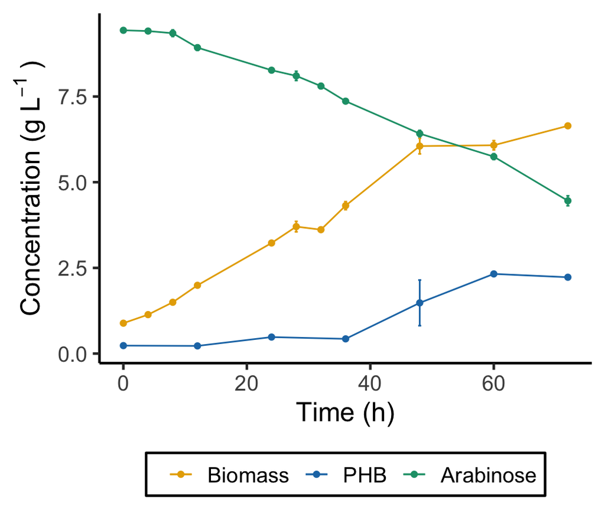

```r
Arabinose$Variable <- relevel(Arabinose$Variable, ref = "PHB")
Arabinose$Variable <- relevel(Arabinose$Variable, ref = "Biomass")

Arabinose_GG <- ggplot(Arabinose, aes(x = Time, y = Concentration, color = Variable)) +
  geom_line() +
  geom_point() +
  geom_errorbar(aes(ymin = Concentration - se, ymax = Concentration + se), width = 0.5) +
  xlab("Time (h)") +
  ylab("Concentration (g/L)") +
  ylab(expression("Concentration (g" ~ L^-1 ~ ")")) +
  scale_color_manual(name = "", values = color_map2) +
  theme_classic(base_size = 17) +
  theme(legend.position = "bottom",
        legend.background = element_rect(color = "black"),
        legend.margin = margin(5, 5, 5, 5))
Arabinose_GG
```

```r
png("~/Desktop/Freelance Work/Universidad de Antioquia/Natalia Gomez/Halomonas/Prototype Figures/ArabinoseOnly.png",
    width = 140, height = 130, units = 'mm', res = 300)
Arabinose_GG
dev.off()
```

### Glucose

Here we follow the same procedure as with Arabinose.

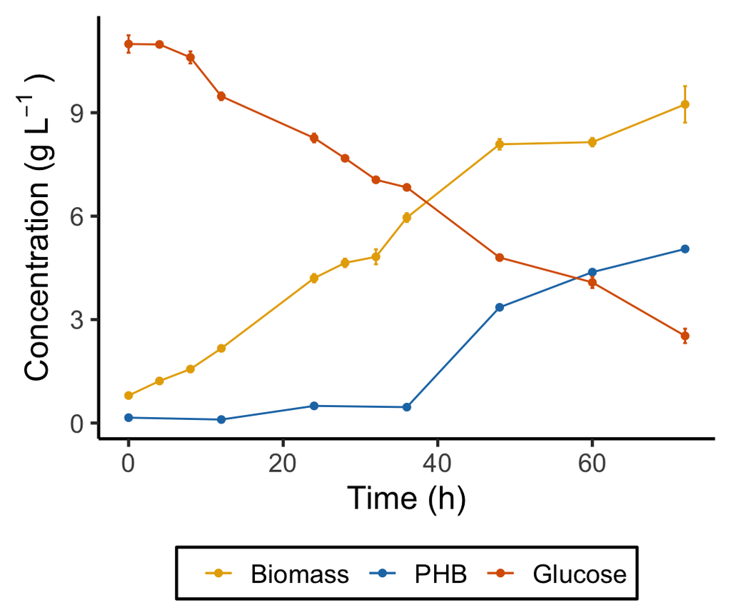

```r
Glucose$Variable <- relevel(Glucose$Variable, ref = "PHB")
Glucose$Variable <- relevel(Glucose$Variable, ref = "Biomass")

Glucose_GG <- ggplot(Glucose, aes(x = Time, y = Concentration, color = Variable)) +
  geom_line() +
  geom_point() +
  geom_errorbar(aes(ymin = Concentration - se, ymax = Concentration + se), width = 0.5) +
  xlab("Time (h)") +
  ylab(expression("Concentration (g" ~ L^-1 ~ ")")) +
  scale_color_manual(name = "", values = color_map2) +
  theme_classic(base_size = 17) +
  theme(legend.position = "bottom",
        legend.background = element_rect(color = "black"),
        legend.margin = margin(5, 5, 5, 5))
Glucose_GG
```

```r
png("~/Desktop/Freelance Work/Universidad de Antioquia/Natalia Gomez/Halomonas/Prototype Figures/GlucoseOnly.png",
    width = 140, height = 130, units = 'mm', res = 300)
Glucose_GG
dev.off()
```

### Xylose

Here we follow the same procedure as with Arabinose.

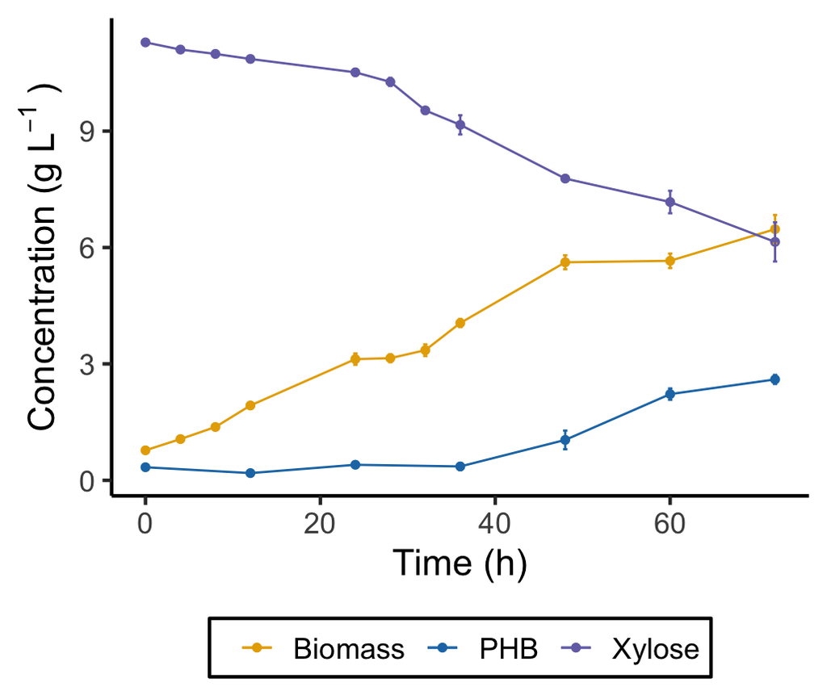

```r
Xylose$Variable <- relevel(Xylose$Variable, ref = "PHB")
Xylose$Variable <- relevel(Xylose$Variable, ref = "Biomass")

Xylose_GG <- ggplot(Xylose, aes(x = Time, y = Concentration, color = Variable)) +
  geom_line() +
  geom_point() +
  geom_errorbar(aes(ymin = Concentration - se, ymax = Concentration + se), width = 0.5) +
  xlab("Time (h)") +
  ylab(expression("Concentration (g" ~ L^-1 ~ ")")) +
  scale_color_manual(name = "", values = color_map2) +
  theme_classic(base_size = 17) +
  theme(legend.position = "bottom",
        legend.background = element_rect(color = "black"),
        legend.margin = margin(5, 5, 5, 5))
Xylose_GG
```

```r
png("~/Desktop/Freelance Work/Universidad de Antioquia/Natalia Gomez/Halomonas/Prototype Figures/XyloseOnly.png",
    width = 140, height = 130, units = 'mm', res = 300)
Xylose_GG
dev.off()
```

### Sugars Together

```r
png("~/Desktop/Freelance Work/Universidad de Antioquia/Natalia Gomez/Halomonas/Prototype Figures/SugarsTogether.png", width = 140, height = 300, units = 'mm', res = 300)
ggarrange(Arabinose_GG, Glucose_GG, Xylose_GG,
          align = 'h', labels = c('(A)', '(B)', '(C)'),
          common.legend = FALSE, nrow = 3, ncol = 1)
dev.off()
```

## Empty Fruit Bunch

For the EFB Hydrolysate we do not need to follow the same number of steps. This is because data for this graph is already formatted in the format we need for ggplot. So, we will start by using the `summarySE` function to calculate means and standard errors by `Time` and `Variable` and then graph and export.

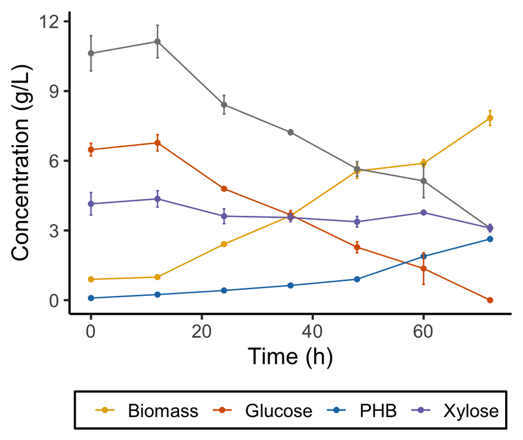

```r
FruitBunch_tgc <- summarySE(FruitBunch, measurevar="Value", groupvars=c("Time", "Variable"), na.rm = TRUE)

FB_GG <- ggplot(FruitBunch_tgc, aes(x = Time, y = Value, color = Variable)) +
  geom_line() +
  geom_point() +
  geom_errorbar(aes(ymin = Value - se, ymax = Value + se), width = 0.5) +
  xlab("Time (h)") +
  ylab("Concentration (g/L)") +
  scale_color_manual(name = "", values = color_map2) +
  theme_classic(base_size = 17) +
  theme(legend.position = "bottom",
        legend.background = element_rect(color = "black"),
        legend.margin = margin(5, 5, 5, 5))
FB_GG
```

```r
png("~/Desktop/Freelance Work/Universidad de Antioquia/Natalia Gomez/Halomonas/Prototype Figures/FruitBunchPHB.png", width = 140, height = 130, units = 'mm', res = 300)
FB_GG
dev.off()
```

# Statistics

Beautiful. Now we are ready to start calculating some key statistics. To do so, first we need to isolate some key numbers, such as the initial and final concentrations of substrate, PHB, and biomass. To do this, we will once again use the `subset` and `droplevels` functions to isolate rows where `Time` is equal to zero or 72.

```r
Arabinose0 <- droplevels(subset(Arabinose, Arabinose$Time == "0"))
Arabinose72 <- droplevels(subset(Arabinose, Arabinose$Time == "72"))

Glucose0 <- droplevels(subset(Glucose, Glucose$Time == "0"))
Glucose72 <- droplevels(subset(Glucose, Glucose$Time == "72"))

Xylose0 <- droplevels(subset(Xylose, Xylose$Time == "0"))
Xylose72 <- droplevels(subset(Xylose, Xylose$Time == "72"))
```

Now, we can easily isolate numbers we need.

## Isolating Statistics

### Arabinose

```r
AraInitialSub <- Arabinose0[3,3]
AraFinalSub <- Arabinose72[3,3]

AraInitialBiomass <- Arabinose0[1,3]
AraFinalBiomass <- Arabinose72[1,3]

AraInitialPHB <- Arabinose0[2,3]
AraFinalPHB <- Arabinose72[2,3]

AraBioDiff <- AraFinalBiomass - AraInitialBiomass
AraPHBDiff <- AraFinalPHB - AraInitialPHB
AraConsumption <- AraInitialSub - AraFinalSub

AraYield <- (AraFinalBiomass - AraInitialBiomass) / (AraInitialSub - AraFinalSub)
AraPHBYield <- (AraFinalPHB - AraInitialPHB) / (AraInitialSub - AraFinalSub)
AraPHBRate <- AraPHBDiff/72
AraPercentPHB <- AraFinalPHB/AraFinalBiomass*100
```

### Glucose

```r
GluInitialSub <- Glucose0[3,3]
GluFinalSub <- Glucose72[3,3]

GluInitialBiomass <- Glucose0[1,3]
GluFinalBiomass <- Glucose72[1,3]

GluInitialPHB <- Glucose0[2,3]
GluFinalPHB <- Glucose72[2,3]

GluBioDiff <- GluFinalBiomass - GluInitialBiomass
GluPHBDiff <- GluFinalPHB - GluInitialPHB
GluConsumption <- GluInitialSub - GluFinalSub

GluYield <- (GluFinalBiomass - GluInitialBiomass) / (GluInitialSub - GluFinalSub)
GluPHBYield <- (GluFinalPHB - GluInitialPHB) / (GluInitialSub - GluFinalSub)
GluPHBRate <- GluPHBDiff/72
GluPercentPHB <- GluFinalPHB/GluFinalBiomass*100
```

### Xylose

```r
XylInitialSub <- Xylose0[3,3]
XylFinalSub <- Xylose72[3,3]

XylInitialBiomass <- Xylose0[1,3]
XylFinalBiomass <- Xylose72[1,3]

XylInitialPHB <- Xylose0[2,3]
XylFinalPHB <- Xylose72[2,3]

XylBioDiff <- XylFinalBiomass - XylInitialBiomass
XylConsumption <- XylInitialSub - XylFinalSub
XylPHBDiff <- XylFinalPHB - XylInitialPHB

XylYield <- (XylFinalBiomass - XylInitialBiomass) / (XylInitialSub - XylFinalSub)
XylPHBYield <- (XylFinalPHB - XylInitialPHB) / (XylInitialSub - XylFinalSub)
XylPHBRate <- XylPHBDiff/72
XylPercentPHB <- XylFinalPHB/XylFinalBiomass*100
```

### EFB

For the EFB, first we need to create a new column `Variable2` in the `FruitBunch` dataframe. The values of `Variable2` are based on the values in the existing `Variable` column. Specifically, if the value in the `Variable` column is “`Glucose`” or “`Xylose`”, the corresponding value in the `Variable2` column is set to “`Sugar`”. For all other values in the `Variable` column, `Variable2` is set to the same value as `Variable`. This will allow us to calculate statistics for the substrate not separated by sugar.

```r
FruitBunch <- FruitBunch %>%
  mutate(Variable2 = ifelse(Variable == "Glucose" | Variable == "Xylose", "Sugar", as.character(Variable)))
```

Now we use the `summarySE` function to calculate descriptive statistics using the `Time` and `Variable2` columns.

```r
FruitBunch2_tgc <- summarySE(FruitBunch, measurevar="Value", groupvars=c("Time", "Variable2"), na.rm = TRUE)
```

We can now isolate Time = 0 or 72.

```r
FruitBunch3_tgc <- FruitBunch2_tgc %>%
  filter(Time == 0 | Time == 72)
```

Now we can isolate the statistics that we are interested in.

```r
EFBInitialBiomass <- FruitBunch3_tgc[1,4]
EFBFinalBiomass <- FruitBunch3_tgc[5,4]

EFBInitialPHB <- FruitBunch3_tgc[2,4]
EFBFinalPHB <- FruitBunch3_tgc[6,4]

EFBInitialSub <- FruitBunch3_tgc[3,4]
EFBFinalSub <- FruitBunch3_tgc[7,4]

EFBBioDiff <- EFBFinalBiomass - EFBInitialBiomass
EFBConsumption <- EFBInitialSub - EFBFinalSub
EFBPHBDiff <- EFBFinalPHB - EFBInitialPHB

EFBYield <- (EFBFinalBiomass - EFBInitialBiomass) / (EFBInitialSub - EFBFinalSub)
EFBPHBYield <- (EFBFinalPHB - EFBInitialPHB) / (EFBInitialSub - EFBFinalSub)
EFBPHBRate <- EFBPHBDiff/72
EFBPercentPHB <- EFBFinalPHB/EFBFinalBiomass*100
```

## Initial Substrate

```r
print(paste("Arabinose Initial Concentration:", round(AraInitialSub,2), "±", round(Arabinose0[1,4],2)))
```

```
## [1] "Arabinose Initial Concentration: 9.43 ± 0.03"
```

```r
print(paste("Glucose Initial Concentration:", round(GluInitialSub,2), "±", round(Glucose0[1,4],2)))
```

```
## [1] "Glucose Initial Concentration: 10.99 ± 0.01"
```

```r
print(paste("Xylose Initial Concentration:", round(XylInitialSub,2), "±", round(Xylose0[1,4],2)))
```

```
## [1] "Xylose Initial Concentration: 11.29 ± 0.01"
```

```r
print(paste("EFB Substrate Initial Concentration:", round(EFBInitialSub,2), "±", round(FruitBunch3_tgc[3,6],2)))
```

```
## [1] "EFB Substrate Initial Concentration: 10.63 ± 0.76"
```

## Consumed Substrate

In order to have the standard error that accompanies this statistic, we’ll need to write some code first.

```r
EFB_Sugars5 <- EFB_Sugars2[(EFB_Sugars2$Time == 0 | EFB_Sugars2$Time == 72) & !(EFB_Sugars2$Replicate %in% c("X1", "A2")), ]

time_0 <- EFB_Sugars5 %>% filter(Time == 0)
time_72 <- EFB_Sugars5 %>% filter(Time == 72)

Sugars0_72 <- merge(time_0, time_72, by = "Sugar", suffixes = c("_0", "_72"))

Sugars0_72$Difference <- Sugars0_72$Sugar_Concentration_72 - Sugars0_72$Sugar_Concentration_0

Sugars0_72_tgc <- summarySE(Sugars0_72, measurevar="Difference", groupvars=c("Sugar"), na.rm = TRUE)

FruitBunch2 <- FruitBunch[(FruitBunch$Time == 0 | FruitBunch$Time == 72) & FruitBunch$Variable == "Substrate", ]

time_0_EFB <- FruitBunch2 %>% filter(Time == 0)
time_72_EFB <- FruitBunch2 %>% filter(Time == 72)

time_72_EFB <- setNames(time_72_EFB, paste0(names(time_72_EFB), "_72"))

EFB_0_72 <- cbind(time_0_EFB, time_72_EFB)

EFB_0_72$Difference <- (EFB_0_72$Value - EFB_0_72$Value_72)
EFB0_72_tgc <- summarySE(EFB_0_72, measurevar="Difference", groupvars=c("Variable2"), na.rm = TRUE)
```

```r
print(paste("Arabinose Consumed Substrate Concentration:", round(AraConsumption,2), "±", round(Sugars0_72_tgc[1,5],2)))
```

```
## [1] "Arabinose Consumed Substrate Concentration: 4.97 ± 0.02"
```

```r
print(paste("Glucose Consumed Substrate Concentration:", round(GluConsumption,2), "±", round(Sugars0_72_tgc[2,5],2)))
```

```
## [1] "Glucose Consumed Substrate Concentration: 8.47 ± 0.16"
```

```r
print(paste("Xylose Consumed Substrate Concentration:", round(XylConsumption,2), "±", round(Sugars0_72_tgc[3,5],2)))
```

```
## [1] "Xylose Consumed Substrate Concentration: 5.14 ± 0.35"
```

```r
print(paste("EFB Consumed Substrate Concentration:", round(EFBConsumption,2), "±", round(EFB0_72_tgc[1,5],2)))
```

```
## [1] "EFB Consumed Substrate Concentration: 7.52 ± 0.77"
```

## Produced Biomass

```r
EFB_Biomass2 <- EFB_Biomass[EFB_Biomass$Time %in% c(0, 72), ]

time_0 <- EFB_Biomass2 %>% filter(Time == 0)
time_72 <- EFB_Biomass2 %>% filter(Time == 72)

Biomass0_72 <- merge(time_0, time_72, by = "Sugar", suffixes = c("_0", "_72"))

Biomass0_72$Difference <- Biomass0_72$Biomass_Concentration_72 - Biomass0_72$Biomass_Concentration_0

Biomass0_72_tgc <- summarySE(Biomass0_72, measurevar="Difference", groupvars=c("Sugar"), na.rm = TRUE)


FruitBunch3 <- FruitBunch[(FruitBunch$Time == 0 | FruitBunch$Time == 72) & FruitBunch$Variable == "Biomass", ]

time_0_EFB <- FruitBunch3 %>% filter(Time == 0)
time_72_EFB <- FruitBunch3 %>% filter(Time == 72)

time_72_EFB <- setNames(time_72_EFB, paste0(names(time_72_EFB), "_72"))

EFB_0_72 <- cbind(time_0_EFB, time_72_EFB)

EFB_0_72$Difference <- (EFB_0_72$Value_72 - EFB_0_72$Value)
EFB0_72_tgcB <- summarySE(EFB_0_72, measurevar="Difference", groupvars=c("Variable2"), na.rm = TRUE)
EFB0_72_tgcB
```

```
##   Variable2 N Difference        sd        se       ci
## 1   Biomass 3   6.939694 0.5586428 0.3225326 1.387746
```

```r
print(paste("Arabinose Produced Biomass Concentration:", round(AraBioDiff, 2), "±", round(Biomass0_72_tgc[1, 5], 2)))
```

```
## [1] "Arabinose Produced Biomass Concentration: 5.76 ± 0.02"
```

```r
print(paste("Glucose Produced Biomass Concentration:", round(GluBioDiff, 2), "±", round(Biomass0_72_tgc[2, 5], 2)))
```

```
## [1] "Glucose Produced Biomass Concentration: 8.44 ± 0.26"
```

```r
print(paste("Xylose Produced Biomass Concentration:", round(XylBioDiff, 2), "±", round(Biomass0_72_tgc[3, 5], 2)))
```

```
## [1] "Xylose Produced Biomass Concentration: 5.7 ± 0.18"
```

```r
print(paste("EFB Produced Biomass Concentration:", round(EFBBioDiff, 2), "±", round(EFB0_72_tgcB[1, 5], 2)))
```

```
## [1] "EFB Produced Biomass Concentration: 6.94 ± 0.32"
```

## Produced PHB

```r
EFB_PHB2 <- EFB_PHB[EFB_PHB$Time %in% c(0, 72), ]

time_0 <- EFB_PHB2 %>% filter(Time == 0)
time_72 <- EFB_PHB2 %>% filter(Time == 72)

PHB0_72 <- merge(time_0, time_72, by = "Sugar", suffixes = c("_0", "_72"))

PHB0_72$Difference <- PHB0_72$PHB_Concentration_72 - PHB0_72$PHB_Concentration_0

PHB0_72_tgc <- summarySE(PHB0_72, measurevar="Difference", groupvars=c("Sugar"), na.rm = TRUE)


FruitBunch4 <- FruitBunch[(FruitBunch$Time == 0 | FruitBunch$Time == 72) & FruitBunch$Variable == "PHB", ]

time_0_EFB <- FruitBunch4 %>% filter(Time == 0)
time_72_EFB <- FruitBunch4 %>% filter(Time == 72)

time_72_EFB <- setNames(time_72_EFB, paste0(names(time_72_EFB), "_72"))

EFB_0_72 <- cbind(time_0_EFB, time_72_EFB)

EFB_0_72$Difference <- (EFB_0_72$Value_72 - EFB_0_72$Value)
EFB0_72_tgcC <- summarySE(EFB_0_72, measurevar="Difference", groupvars=c("Variable2"), na.rm = TRUE)
EFB0_72_tgcC
```

```
##   Variable2 N Difference sd se ci
## 1       PHB 1      2.541 NA NA NA
```

```r
print(paste("Arabinose Produced PHB Concentration:", round(AraPHBDiff, 2), "±", round(PHB0_72_tgc[1, 5], 2)))
```

```
## [1] "Arabinose Produced PHB Concentration: 1.99 ± 0.03"
```

```r
print(paste("Glucose Produced PHB Concentration:", round(GluPHBDiff, 2), "±", round(PHB0_72_tgc[2, 5], 2)))
```

```
## [1] "Glucose Produced PHB Concentration: 4.89 ± 0.03"
```

```r
print(paste("Xylose Produced PHB Concentration:", round(XylPHBDiff, 2), "±", round(PHB0_72_tgc[3, 5], 2)))
```

```
## [1] "Xylose Produced PHB Concentration: 2.26 ± 0.12"
```

```r
print(paste("EFB Produced PHB Concentration:", round(EFBPHBDiff, 2), "±", round(EFB0_72_tgcC[1, 5], 2)))
```

```
## [1] "EFB Produced PHB Concentration: 2.54 ± NA"
```

## Biomass Yield

```r
print(paste("Arabinose Biomass Yield:", round(AraYield, 2)))
```

```
## [1] "Arabinose Biomass Yield: 1.16"
```

```r
print(paste("Glucose Biomass Yield:", round(GluYield, 2)))
```

```
## [1] "Glucose Biomass Yield: 1"
```

```r
print(paste("Xylose Biomass Yield:", round(XylYield, 2)))
```

```
## [1] "Xylose Biomass Yield: 1.11"
```

```r
print(paste("EFB Biomass Yield:", round(EFBYield, 2)))
```

```
## [1] "EFB Biomass Yield: 0.92"
```

## PHB Yield

```r
print(paste("Arabinose Biomass Yield:", round(AraPHBYield, 2)))
```

```
## [1] "Arabinose Biomass Yield: 0.4"
```

```r
print(paste("Glucose Biomass Yield:", round(GluPHBYield, 2)))
```

```
## [1] "Glucose Biomass Yield: 0.58"
```

```r
print(paste("Xylose Biomass Yield:", round(XylPHBYield, 2)))
```

```
## [1] "Xylose Biomass Yield: 0.44"
```

```r
print(paste("EFB Biomass Yield:", round(EFBPHBYield, 2)))
```

```
## [1] "EFB Biomass Yield: 0.34"
```

## μmax

```r
Arabinose_μmax <- Arabinose[!(Arabinose$Time %in% c(4, 8, 28, 32)) & Arabinose$Variable != "PHB", ][,-4]

Arabinose_μmax_wide <- Arabinose_μmax %>%
  tidyr::pivot_wider(names_from = Variable, values_from = Concentration)

Arabinose_μmax_wide <- Arabinose_μmax_wide %>%
  dplyr::arrange(Time) %>%
  dplyr::mutate(dx_dt = (lead(Biomass) - Biomass) / (dplyr::lead(Time) - Time))

Arabinose_μmax_wide <- Arabinose_μmax_wide %>%
  arrange(Time) %>%
  mutate(s = (Arabinose + lead(Arabinose)) / 2)

Arabinose_μmax_wide <- Arabinose_μmax_wide %>%
  arrange(Time) %>%
  mutate(dx_dt_ave = (dx_dt + lead(dx_dt)) / 2)

Arabinose_μmax_wide$s1 <- 1/Arabinose_μmax_wide$s

Arabinose_μmax_wide <- Arabinose_μmax_wide %>%
  arrange(Time) %>%
  mutate(x = (Biomass + lead(Biomass)) / 2)

Arabinose_μmax_wide$u <- Arabinose_μmax_wide$dx_dt_ave / Arabinose_μmax_wide$x

Arabinose_μmax_wide$u1 <- 1/Arabinose_μmax_wide$u
Arabinose_μmax_wide
```

```
## # A tibble: 7 × 11
##    Time Sugar   Biomass Arabinose    dx_dt     s dx_dt_ave     s1     x        u
##   <dbl> <fct>     <dbl>     <dbl>    <dbl> <dbl>     <dbl>  <dbl> <dbl>    <dbl>
## 1     0 Arabin…   0.886      9.43  0.0921   9.18    0.0975  0.109  1.44  0.0677
## 2    12 Arabin…   1.99       8.93  0.103    8.60    0.0969  0.116  2.61  0.0371
## 3    24 Arabin…   3.23       8.27  0.0908   7.82    0.118   0.128  3.77  0.0312
## 4    36 Arabin…   4.32       7.36  0.145    6.89    0.0734  0.145  5.18  0.0142
## 5    48 Arabin…   6.05       6.42  0.00199  6.08    0.0246  0.164  6.06  0.00406
## 6    60 Arabin…   6.08       5.75  0.0473   5.10   NA       0.196  6.36 NA
## 7    72 Arabin…   6.64       4.46 NA       NA      NA      NA     NA    NA
## # ℹ 1 more variable: u1 <dbl>
```

```r
Glucose_μmax <- Glucose[!(Glucose$Time %in% c(4, 8, 28, 32)) & Glucose$Variable != "PHB", ][,-4]

Glucose_μmax_wide <- Glucose_μmax %>%
  tidyr::pivot_wider(names_from = Variable, values_from = Concentration)

Glucose_μmax_wide <- Glucose_μmax_wide %>%
  dplyr::arrange(Time) %>%
  dplyr::mutate(dx_dt = (lead(Biomass) - Biomass) / (dplyr::lead(Time) - Time))

Glucose_μmax_wide <- Glucose_μmax_wide %>%
  arrange(Time) %>%
  mutate(s = (Glucose + lead(Glucose)) / 2)

Glucose_μmax_wide <- Glucose_μmax_wide %>%
  arrange(Time) %>%
  mutate(dx_dt_ave = (dx_dt + lead(dx_dt)) / 2)

Glucose_μmax_wide$s1 <- 1/Glucose_μmax_wide$s

Glucose_μmax_wide <- Glucose_μmax_wide %>%
  arrange(Time) %>%
  mutate(x = (Biomass + lead(Biomass)) / 2)

Glucose_μmax_wide$u <- Glucose_μmax_wide$dx_dt_ave / Glucose_μmax_wide$x

Glucose_μmax_wide$u1 <- 1/Glucose_μmax_wide$u
Glucose_μmax_wide
```

```
## # A tibble: 7 × 11
##    Time Sugar   Biomass Glucose    dx_dt     s dx_dt_ave      s1     x        u
##   <dbl> <fct>     <dbl>   <dbl>    <dbl> <dbl>     <dbl>   <dbl> <dbl>    <dbl>
## 1     0 Glucose   0.798   11.0   0.114   10.2     0.142   0.0977  1.48  0.0957
## 2    12 Glucose   2.17     9.48  0.170    8.87    0.158   0.113   3.18  0.0497
## 3    24 Glucose   4.20     8.27  0.146    7.55    0.162   0.132   5.08  0.0318
## 4    36 Glucose   5.96     6.83  0.177    5.82    0.0911  0.172   7.02  0.0130
## 5    48 Glucose   8.08     4.80  0.00516  4.44    0.0483  0.225   8.11  0.00595
## 6    60 Glucose   8.15     4.08  0.0914   3.30   NA       0.303   8.69 NA
## 7    72 Glucose   9.24     2.53 NA       NA      NA      NA      NA    NA
## # ℹ 1 more variable: u1 <dbl>
```

```r
Xylose_μmax <- Xylose[!(Xylose$Time %in% c(4, 8, 28, 32)) & Xylose$Variable != "PHB", ][,-4]

Xylose_μmax_wide <- Xylose_μmax %>%
  tidyr::pivot_wider(names_from = Variable, values_from = Concentration)

Xylose_μmax_wide <- Xylose_μmax_wide %>%
  dplyr::arrange(Time) %>%
  dplyr::mutate(dx_dt = (lead(Biomass) - Biomass) / (dplyr::lead(Time) - Time))

Xylose_μmax_wide <- Xylose_μmax_wide %>%
  arrange(Time) %>%
  mutate(s = (Xylose + lead(Xylose)) / 2)

Xylose_μmax_wide <- Xylose_μmax_wide %>%
  arrange(Time) %>%
  mutate(dx_dt_ave = (dx_dt + lead(dx_dt)) / 2)

Xylose_μmax_wide$s1 <- 1/Xylose_μmax_wide$s

Xylose_μmax_wide <- Xylose_μmax_wide %>%
  arrange(Time) %>%
  mutate(x = (Biomass + lead(Biomass)) / 2)

Xylose_μmax_wide$u <- Xylose_μmax_wide$dx_dt_ave / Xylose_μmax_wide$x

Xylose_μmax_wide$u1 <- 1/Xylose_μmax_wide$u
Xylose_μmax_wide
```

```
## # A tibble: 7 × 11
##    Time Sugar  Biomass Xylose    dx_dt     s dx_dt_ave      s1     x        u
##   <dbl> <fct>    <dbl>  <dbl>    <dbl> <dbl>     <dbl>   <dbl> <dbl>    <dbl>
## 1     0 Xylose   0.773  11.3   0.0963  11.1     0.0979  0.0903  1.35  0.0725
## 2    12 Xylose   1.93   10.9   0.0995  10.7     0.0886  0.0936  2.53  0.0351
## 3    24 Xylose   3.12   10.5   0.0776   9.84    0.104   0.102   3.59  0.0290
## 4    36 Xylose   4.05    9.16  0.130    8.47    0.0668  0.118   4.84  0.0138
## 5    48 Xylose   5.62    7.78  0.00318  7.47    0.0356  0.134   5.64  0.00631
## 6    60 Xylose   5.66    7.17  0.0679   6.66   NA       0.150   6.06 NA
## 7    72 Xylose   6.47    6.14 NA       NA      NA      NA      NA    NA
## # ℹ 1 more variable: u1 <dbl>
```

```r
FruitBunch_tgc_μmax <- FruitBunch_tgc[!(FruitBunch_tgc$Time %in% c(4, 8, 28, 32)) &
                                      !(FruitBunch_tgc$Variable %in% c("PHB", "Glucose", "Xylose")), ][,-c(3,5,6,7)]


FruitBunch_tgc_μmax_wide <- FruitBunch_tgc_μmax %>%
  tidyr::pivot_wider(names_from = Variable, values_from = Value)

FruitBunch_tgc_μmax_wide <- FruitBunch_tgc_μmax_wide %>%
  dplyr::arrange(Time) %>%
  dplyr::mutate(dx_dt = (lead(Biomass) - Biomass) / (dplyr::lead(Time) - Time))

FruitBunch_tgc_μmax_wide <- FruitBunch_tgc_μmax_wide %>%
  arrange(Time) %>%
  mutate(s = (Substrate + lead(Substrate)) / 2)

FruitBunch_tgc_μmax_wide <- FruitBunch_tgc_μmax_wide %>%
  arrange(Time) %>%
  mutate(dx_dt_ave = (dx_dt + lead(dx_dt)) / 2)

FruitBunch_tgc_μmax_wide$s1 <- 1/FruitBunch_tgc_μmax_wide$s

FruitBunch_tgc_μmax_wide <- FruitBunch_tgc_μmax_wide %>%
  arrange(Time) %>%
  mutate(x = (Biomass + lead(Biomass)) / 2)

FruitBunch_tgc_μmax_wide$u <- FruitBunch_tgc_μmax_wide$dx_dt_ave / FruitBunch_tgc_μmax_wide$x

FruitBunch_tgc_μmax_wide$u1 <- 1/FruitBunch_tgc_μmax_wide$u
FruitBunch_tgc_μmax_wide
```

```
## # A tibble: 7 × 10
##    Time Biomass Substrate    dx_dt     s dx_dt_ave      s1      x       u    u1
##   <dbl>   <dbl>     <dbl>    <dbl> <dbl>     <dbl>   <dbl>  <dbl>   <dbl> <dbl>
## 1     0   0.897     10.6   0.00803 10.9     0.0630  0.0919  0.945  0.0667  15.0
## 2    12   0.993     11.1   0.118    9.77    0.110   0.102   1.70   0.0646  15.5
## 3    24   2.41       8.41  0.102    7.82    0.131   0.128   3.02   0.0434  23.0
## 4    36   3.63       7.23  0.161    6.44    0.0942  0.155   4.59   0.0205  48.8
## 5    48   5.56       5.65  0.0278   5.39    0.0950  0.185   5.72   0.0166  60.3
## 6    60   5.89       5.13  0.162    4.12   NA       0.243   6.86  NA       NA
## 7    72   7.84       3.10 NA       NA      NA      NA      NA     NA       NA
```

#### Arabinose

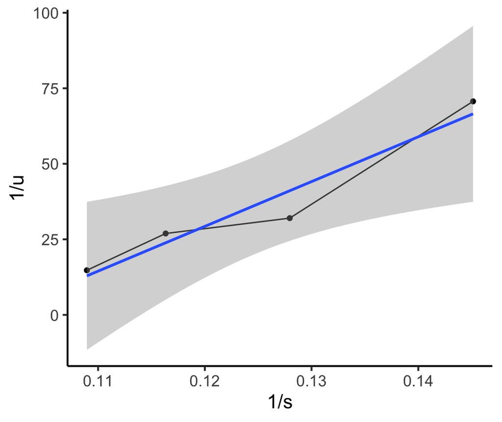

```r
ggplot(Arabinose_μmax_wide[c(1:4),], aes(x = s1, y = u1)) +
  geom_point() +
  geom_line() +
  geom_smooth(method = "lm") +
  xlab("1/s") +
  ylab("1/u") +
  theme_classic(base_size = 15)
```

```r
Aramodel <- lm(u1 ~ s1, data = Arabinose_μmax_wide[c(1:4),])
Araslope <- coef(Aramodel)[2]
Araintercept <- coef(Aramodel)[1]
Araequation <- paste0("y = ", round(Araintercept, 2), " + ", round(Araslope, 2), "x")
Araequation
```

```
## [1] "y = -148.55 + 1481.99x"
```

```r
Ara_μmax <- 1/Araintercept
Ara_ks <- Ara_μmax*-1*Araslope
```

#### Glucose

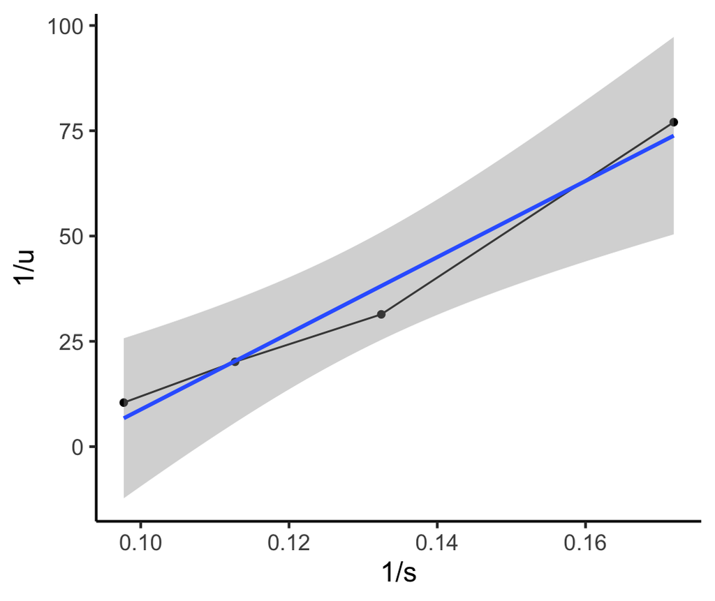

```r
ggplot(Glucose_μmax_wide[c(1:4),], aes(x = s1, y = u1)) +
  geom_point() +
  geom_line() +
  geom_smooth(method = "lm") +
  xlab("1/s") +
  ylab("1/u") +
  theme_classic(base_size = 15)
```

```r
Glumodel <- lm(u1 ~ s1, data = Glucose_μmax_wide[c(1:4),])
Gluslope <- coef(Glumodel)[2]
Gluintercept <- coef(Glumodel)[1]
Gluequation <- paste0("y = ", round(Gluintercept, 2), " + ", round(Gluslope, 2), "x")
Gluequation
```

```
## [1] "y = -81.66 + 904.59x"
```

```r
Glu_μmax <- 1/Gluintercept
Glu_ks <- Glu_μmax*-1*Gluslope
```

#### Xylose

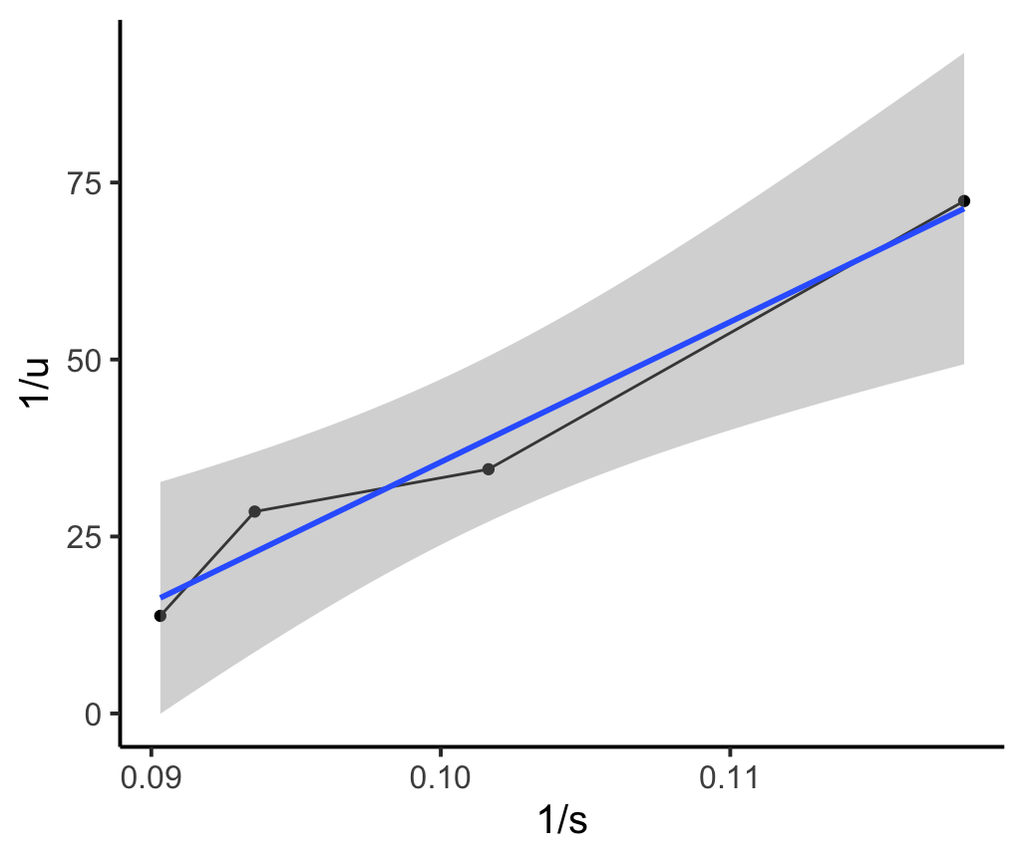

```r
ggplot(Xylose_μmax_wide[c(1:4),], aes(x = s1, y = u1)) +
  geom_point() +
  geom_line() +
  geom_smooth(method = "lm") +
  xlab("1/s") +
  ylab("1/u") +
  theme_classic(base_size = 15)
```

```r
Xylmodel <- lm(u1 ~ s1, data = Xylose_μmax_wide[c(1:4),])
Xylslope <- coef(Xylmodel)[2]
Xylintercept <- coef(Xylmodel)[1]
Xylequation <- paste0("y = ", round(Xylintercept, 2), " + ", round(Xylslope, 2), "x")
Xylequation
```

```
## [1] "y = -162.52 + 1980.31x"
```

```r
Xyl_μmax <- 1/Xylintercept
Xyl_ks <- Xyl_μmax*-1*Xylslope
```

#### EFB

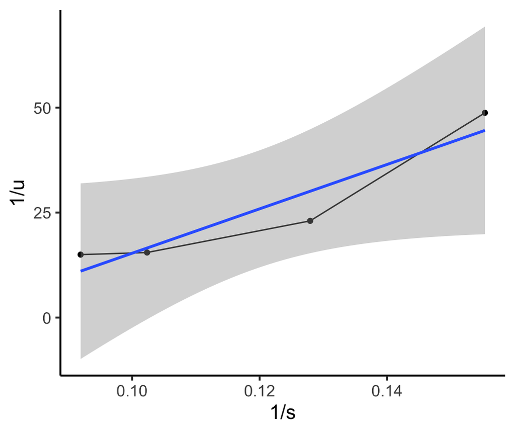

```r
ggplot(FruitBunch_tgc_μmax_wide[c(1:4),], aes(x = s1, y = u1)) +
  geom_point() +
  geom_line() +
  geom_smooth(method = "lm") +
  xlab("1/s") +
  ylab("1/u") +
  theme_classic(base_size = 15)
```

```r
EFBmodel <- lm(u1 ~ s1, data = FruitBunch_tgc_μmax_wide[c(1:4),])
EFBslope <- coef(EFBmodel)[2]
EFBintercept <- coef(EFBmodel)[1]
EFBequation <- paste0("y = ", round(EFBintercept, 2), " + ", round(EFBslope, 2), "x")
EFBequation
```

```
## [1] "y = -37.57 + 528.84x"
```

```r
EFB_μmax <- 1/EFBintercept
EFB_ks <- EFB_μmax*-1*EFBslope
```

```r
print(paste("Arabinose μmax:", round(Ara_μmax, 3)))
```

```
## [1] "Arabinose μmax: -0.007"
```

```r
print(paste("Glucose μmax:", round(Glu_μmax, 3)))
```

```
## [1] "Glucose μmax: -0.012"
```

```r
print(paste("Xylose μmax:", round(Xyl_μmax, 3)))
```

```
## [1] "Xylose μmax: -0.006"
```

```r
print(paste("EFB μmax:", round(EFB_μmax, 3)))
```

```
## [1] "EFB μmax: -0.027"
```

## ks

```r
print(paste("Arabinose ks:", round(Ara_ks, 3)))
```

```
## [1] "Arabinose ks: 9.976"
```

```r
print(paste("Glucose ks:", round(Glu_ks, 3)))
```

```
## [1] "Glucose ks: 11.078"
```

```r
print(paste("Xylose ks:", round(Xyl_ks, 3)))
```

```
## [1] "Xylose ks: 12.185"
```

```r
print(paste("EFB ks:", round(EFB_ks, 3)))
```

```
## [1] "EFB ks: 14.077"
```

## PHB (%)

```r
print(paste("Arabinose Biomass Yield:", round(AraPercentPHB, 2), "%"))
```

```
## [1] "Arabinose Biomass Yield: 33.52 %"
```

```r
print(paste("Glucose Biomass Yield:", round(GluPercentPHB, 2), "%"))
```

```
## [1] "Glucose Biomass Yield: 54.63 %"
```

```r
print(paste("Xylose Biomass Yield:", round(XylPercentPHB, 2), "%"))
```

```
## [1] "Xylose Biomass Yield: 40.18 %"
```

```r
print(paste("EFB Biomass Yield:", round(EFBPercentPHB, 2), "%"))
```

```
## [1] "EFB Biomass Yield: 33.59 %"
```

# Statistical Analysis

## Consumed Sugar

### Glucose

This has to be extracted from the previously calculated statistics for the graphs, given that outliers have been removed, but joint averages are still used.

```r
Glucose072<- Glucose %>%
  filter(Time == 0 | Time == 72)

Glucose072[5,3] - Glucose072[6,3]
```

```
## [1] 8.465975
```

```r
sqrt((Glucose072[5,4]^2) + (Glucose072[6,4]^2))
```

```
## [1] 0.3273601
```

### Arabinose

This has to be extracted from the previously calculated statistics for the graphs, given that outliers have been removed, but joint averages are still used.

```r
Arabinose072<- Arabinose %>%
  filter(Time == 0 | Time == 72)

Arabinose072[5,3] - Arabinose072[6,3]
```

```
## [1] 4.973402
```

```r
sqrt((Arabinose072[5,4]^2) + (Arabinose072[6,4]^2))
```

```
## [1] 0.1484449
```

### Xylose

This has to be extracted from the previously calculated statistics for the graphs, given that outliers have been removed, but joint averages are still used.

```r
Xylose072<- Xylose %>%
  filter(Time == 0 | Time == 72)

Xylose072[5,3] - Xylose072[6,3]
```

```
## [1] 5.14253
```

```r
sqrt((Xylose072[5,4]^2) + (Xylose072[6,4]^2))
```

```
## [1] 0.5080001
```

```r
EFB_Sugars3 <- EFB_Sugars2 %>%
  filter(Time == 0 | Time == 72)

EFB_Sugars4 <- EFB_Sugars3 %>% # Arabinose had its Time = 0 excluded as outlier.
  group_by(Sugar, Replicate) %>%
  mutate(ConsumedSugar = Sugar_Concentration - lag(Sugar_Concentration, default = first(Sugar_Concentration))) %>%
  ungroup()

EFB_Sugars4 <- EFB_Sugars4 %>%
  filter(Time == 72 & Replicate != "A2")

EFB_Sugars4 <- EFB_Sugars4 %>%
  filter(Time == 72 & Replicate != "X1")

EFB_Sugars4$ConsumedSugar <- EFB_Sugars4$ConsumedSugar*-1

summarySE(EFB_Sugars4, measurevar="ConsumedSugar", groupvars=c("Sugar"), na.rm = TRUE)[,c(1,3,5)]
```

```
##       Sugar ConsumedSugar         se
## 1 Arabinose      4.828746 0.04958066
## 2   Glucose      8.465975 0.37712793
## 3    Xylose      4.777906 0.53825900
```

```r
FruitBunch2 <- FruitBunch %>%
  filter(Time == 0 | Time == 72)

FruitBunch2 <- FruitBunch2 %>%
  filter(Variable == "Glucose" | Variable == "Xylose")

FruitBunch2$Replicate <- c("G1", "G1", "G2", "G2", "G3", "G3",
                           "X1", "X1", "X2", "X2", "X3", "X3")

FruitBunch3 <- FruitBunch2 %>%
  group_by(Variable, Replicate) %>%
  mutate(ConsumedSugar = Concentration - lag(Concentration, default = first(Concentration))) %>%
  ungroup()

FruitBunch3$ConsumedSugar <- FruitBunch3$ConsumedSugar*-1
summarySE(FruitBunch3, measurevar="ConsumedSugar", groupvars=c("Variable"), na.rm = TRUE)[,c(1,3,5)]
```

[output not shown]

## Final Biomass

```r
EFB_Biomass2 <- EFB_Biomass %>%
  filter(Time == 72)

summarySE(EFB_Biomass2, measurevar="Biomass_Concentration", groupvars=c("Sugar"), na.rm = TRUE)[,c(1,3,5)]
```

```
##       Sugar Biomass_Concentration         se
## 1 Arabinose              6.644188 0.01651453
## 2   Glucose              9.242385 0.52848637
## 3    Xylose              6.472564 0.36584430
```

```r
FruitBunch4 <- FruitBunch %>%
  filter(Variable == "Biomass")

FruitBunch4 <- FruitBunch4 %>%
  filter(Time == 72)

summarySE(FruitBunch4, measurevar="Value", groupvars=c("Variable"), na.rm = TRUE)[,c(1,3,5)]
```

```
##   Variable    Value        se
## 1  Biomass 7.836611 0.3215502
```

## ANOVA

### Sugars

First we need to subset so that we only have the sugar concentration at time = 72.

```r
EFB_Sugars3 <- droplevels(subset(EFB_Sugars2, EFB_Sugars2$Time == "72"))

lm1 <- lm(data=EFB_Sugars3, Sugar_Concentration ~ Sugar)
anova(lm1)
```

```
## Analysis of Variance Table
##
## Response: Sugar_Concentration
##           Df Sum Sq Mean Sq F value    Pr(>F)
## Sugar      2 19.657  9.8285  30.891 0.0006936 ***
## Residuals  6  1.909  0.3182
## ---
## Signif. codes:  0 '***' 0.001 '**' 0.01 '*' 0.05 '.' 0.1 ' ' 1
```

```r
summary(glht(lm1, linfct = mcp(Sugar = "Tukey")), test = adjusted("holm"))
```

```
##
##   Simultaneous Tests for General Linear Hypotheses
##
## Multiple Comparisons of Means: Tukey Contrasts
##
##
## Fit: lm(formula = Sugar_Concentration ~ Sugar, data = EFB_Sugars3)
##
## Linear Hypotheses:
##                          Estimate Std. Error t value Pr(>|t|)
## Glucose - Arabinose == 0  -1.9312     0.4606  -4.193 0.011458 *
## Xylose - Arabinose == 0    1.6861     0.4606   3.661 0.011458 *
## Xylose - Glucose == 0      3.6173     0.4606   7.854 0.000676 ***
## ---
## Signif. codes:  0 '***' 0.001 '**' 0.01 '*' 0.05 '.' 0.1 ' ' 1
## (Adjusted p values reported -- holm method)
```

### PHB

```r
EFB_PHB2 <- droplevels(subset(EFB_PHB, EFB_PHB$Time == "72"))

lm2 <- lm(data=EFB_PHB2, PHB_Concentration ~ Sugar)
anova(lm2)
```

```
## Analysis of Variance Table
##
## Response: PHB_Concentration
##           Df Sum Sq Mean Sq F value    Pr(>F)
## Sugar      2 9.4004  4.7002  407.46 0.0002221 ***
## Residuals  3 0.0346  0.0115
## ---
## Signif. codes:  0 '***' 0.001 '**' 0.01 '*' 0.05 '.' 0.1 ' ' 1
```

```r
summary(glht(lm2, linfct = mcp(Sugar = "Tukey")), test = adjusted("holm"))
```

```
##
##   Simultaneous Tests for General Linear Hypotheses
##
## Multiple Comparisons of Means: Tukey Contrasts
##
##
## Fit: lm(formula = PHB_Concentration ~ Sugar, data = EFB_PHB2)
##
## Linear Hypotheses:
##                          Estimate Std. Error t value Pr(>|t|)
## Glucose - Arabinose == 0   2.8222     0.1074  26.277 0.000363 ***
## Xylose - Arabinose == 0    0.3734     0.1074   3.477 0.040156 *
## Xylose - Glucose == 0     -2.4488     0.1074 -22.800 0.000370 ***
## ---
## Signif. codes:  0 '***' 0.001 '**' 0.01 '*' 0.05 '.' 0.1 ' ' 1
## (Adjusted p values reported -- holm method)
```

**Interpretation:** According to the Analysis of Variance (ANOVA), there is a statistically significant difference in the concentration of PHB among the tested sugars after 72 hours (F<sub>2,3</sub> = 407.46, p = **0.0002**). The Tukey Post-Hoc Test revealed statistically significant differences between `Glucose vs Arabinose (t = 26.277, p = 0.0004)` and `Glucose vs Xylose (t = 22.800, p = 0.0004)`. There was also a marginally significant difference between `Xylose vs Arabinose (t = 3.477, p = 0.040156)`.

### Rate of PHB

```r
EFB_PHB2 <- droplevels(subset(EFB_PHB, EFB_PHB$Time == "72"))

EFB_PHB2$Rate <- EFB_PHB2$PHB_Concentration/72


lm3 <- lm(data=EFB_PHB2, Rate ~ Sugar)
anova(lm3)
```

```
## Analysis of Variance Table
##
## Response: Rate
##           Df     Sum Sq    Mean Sq F value    Pr(>F)
## Sugar      2 0.00181335 0.00090667  407.46 0.0002221 ***
## Residuals  3 0.00000668 0.00000223
## ---
## Signif. codes:  0 '***' 0.001 '**' 0.01 '*' 0.05 '.' 0.1 ' ' 1
```

```r
summary(glht(lm3, linfct = mcp(Sugar = "Tukey")), test = adjusted("holm"))
```

```
##
##   Simultaneous Tests for General Linear Hypotheses
##
## Multiple Comparisons of Means: Tukey Contrasts
##
##
## Fit: lm(formula = Rate ~ Sugar, data = EFB_PHB2)
##
## Linear Hypotheses:
##                           Estimate Std. Error t value Pr(>|t|)
## Glucose - Arabinose == 0  0.039197   0.001492  26.277 0.000363 ***
## Xylose - Arabinose == 0   0.005186   0.001492   3.477 0.040156 *
## Xylose - Glucose == 0    -0.034011   0.001492 -22.800 0.000370 ***
## ---
## Signif. codes:  0 '***' 0.001 '**' 0.01 '*' 0.05 '.' 0.1 ' ' 1
## (Adjusted p values reported -- holm method)
```

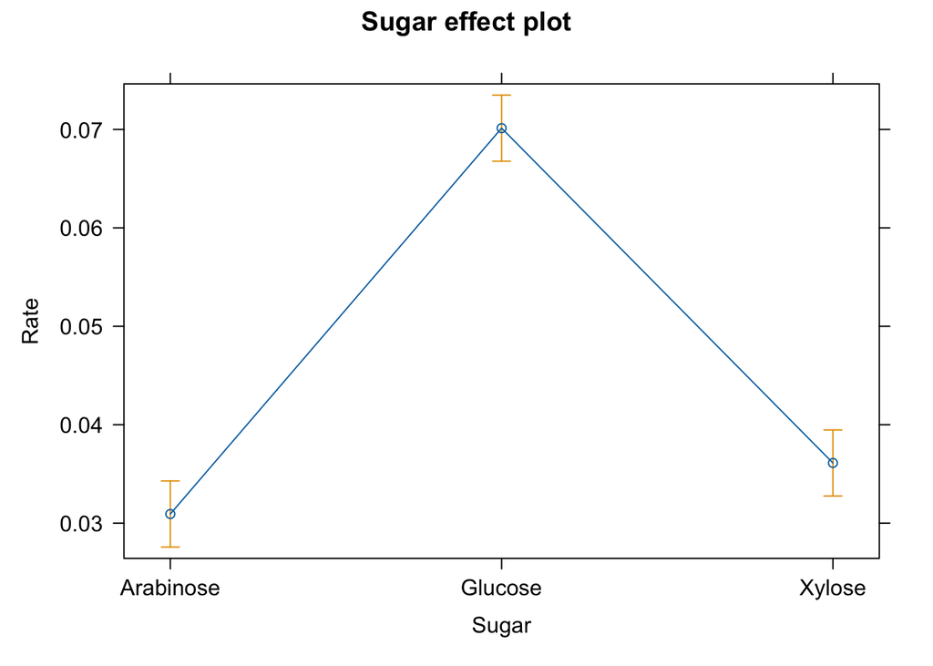

```r
plot(allEffects(lm3))
```

**Interpretation:** According to the Analysis of Variance (ANOVA), there is a statistically significant difference in the rate of PHB accumulation among the tested sugars after 72 hours (F<sub>2,3</sub> = 407.46, p = **0.0002**). The Tukey Post-Hoc Test revealed statistically significant differences between `Glucose vs Arabinose (t = 26.277, p = 0.0004)` and `Glucose vs Xylose (t = 22.800, p = 0.0004)`. There was also a marginally significant difference between `Xylose vs Arabinose (t = 3.477, p = 0.040156)`.